# Portfolio 3: growthrates

ESM 211 Winter 2024

Linus Blomqvist

## What does the package do?

- `growthrates` offers various ways of assessing growth rates (and other growth parameters) in populations
- For example, finding the $r$ in an exponential growth function, or $r_{max}$ and $K$ in a logistic growth function
- Can also estimate dose response curves
- It doesn’t have its own model-fitting routines, but rather serves as a convenient wrapper for other packages

## Application

- The models can be applied to any type of population, from microbes to bison
- For the simplest applications, all you need is a time series of population size
- Can also handle multiple time series from a single experiment (see example)

## Example

- I will use a dataset on bacterial growth that comes with the package
- Three strains of bacteria (D = Donor, R = Recipient, T = transconjugant)
- Different concentrations of the antibiotic tetracycline
- Read off at 31 different times (0:30)
- Two replicates

## Load, inspect, subsample data

This is a lot of wrangling specific to this dataset (and making it more manageable):

```r
# Load dataset and show summary
data(bactgrowth)
summary(bactgrowth)

# Create subsample to fit graphs on one page
bactgrowth_small <- bactgrowth %>%
  filter(conc %in% sample(conc, 4))
```

Some general data inspection.

## Plot data

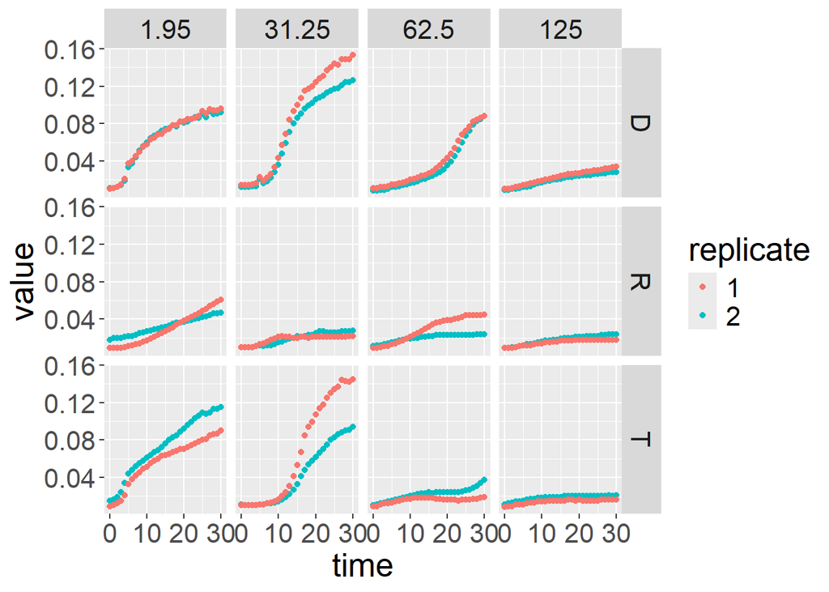

## Simplest case: single dataset (time series)

- Three functions: `fit_easylinear`, `fit_growthmodels`, and `fit_splines`
- For single dataset (just one growth curve), need to subset data

```r
# Subset bactgrowth data
splitted.data <- multisplit(bactgrowth,
                            c("strain", "conc", "replicate"))
dat <- splitted.data[[1]]
```

This includes only strain D, replicate 1, and concentration 0

## Inspect dataset for single growth curve

```r
head(dat %>%
       select(time, value))
```

This is all the data you need to find $r$, $K$, and other parameters. Make sure time starts at 0.

## Plot single growth curve

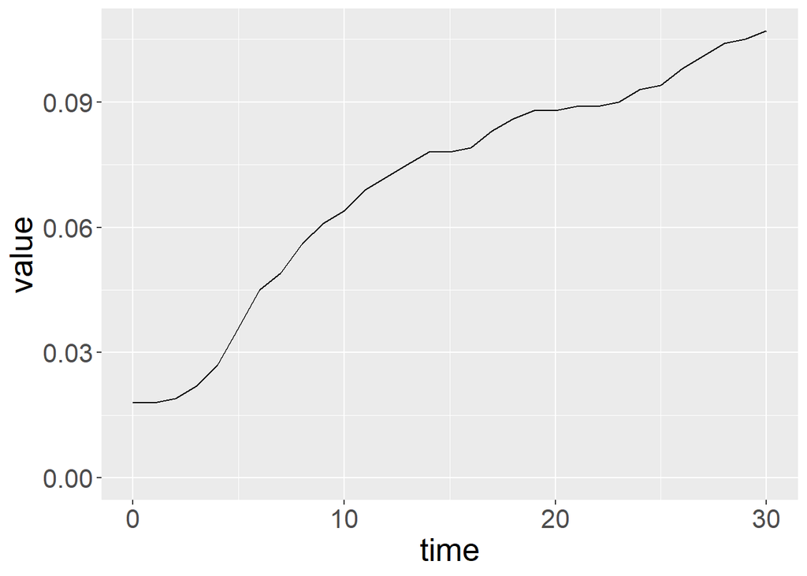

## Finding $r$

Exponential growth:
$$N_t = N_0
e^{rt}$$
Derivative of exponential growth:
$$ln(N_t) = ln(N_0) + rt$$
Can be evaluated as a linear function:

$$y = b_0 + b_1 t$$

where $b_0 = ln(N_0)$ and $b_1 = r$.

## Using `growthrates` to find $r$

The function `fit_easylinear` finds the maximum growth rate on the exponential segment of the growth curve.

`fit_easylinear` takes four arguments:

`fit_easylinear(time, y, h = 5, quota = 0.95)`

- `h` = number of data points (see next slide)
- `quota` = how much of adjacent data to include

## How `fit_easylinear`’s algorithm works

1. Fit linear regressions to all subsets of h consecutive data points. If for example h = 5, fit a linear regression to points 1 . . . 5, 2 . . . 6, 3. . . 7 and so on. The method seeks the highest rate of exponential growth, so the dependent variable is log-transformed.
2. Find the subset with the highest slope bmax and include also the data points of adjacent subsets that have a slope of at least $quota \cdot bmax$, e.g. all data sets that have at least 95% of the maximum slope.
3. Fit a new linear model to the extended data window identified in step 2.

## Applying `fit_easylinear`

```r
fit <- fit_easylinear(dat$time, dat$value)

# Keeping defaults for h and quota

coef(fit)
```

$mumax$ is $r$.

In this case, $r = 0.20$.

Very straightforward.

## Plotting the results

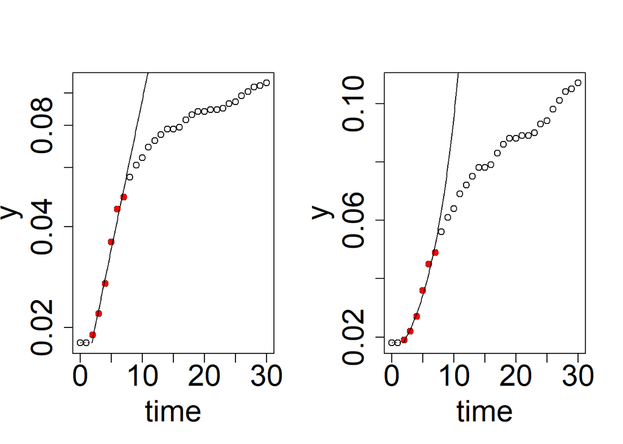

## Using `fit_splines`

Splines fit models piecewise to a dataset, with a polynomial for each segment, and some fancy math to make it nice and smooth.

`growthrates` has the function `fit_splines` that can find $r$ using this method

```r
res <- fit_spline(dat$time, dat$value)

coef(res)
```

In this instance, $r = 0.30$. It’s a bit higher.

## Plotting the result

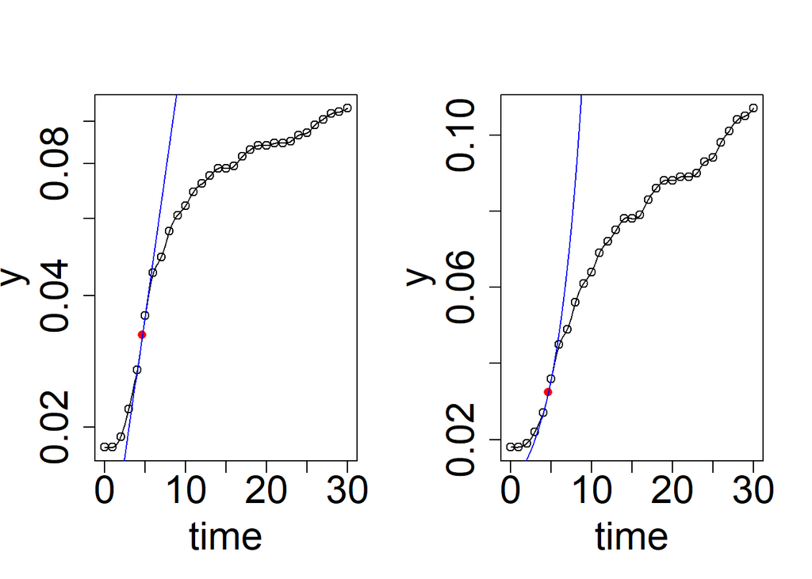

## Fitting parametric nonlinear models

- `growthrates` can also be used to fit parametric nonlinear models with the `fit_growthmodel` function

fit_growthmodel(  
FUN,  
p,  
time,  
y,  
lower = -Inf,  
upper = Inf,  
which = names(p),  
method = “Marq”,  
transform = c(“none”, “log”), control = NULL,  
…)

## Applying `fit_growthmodel`

`FUN` defines the growth model; we will use `FUN = grow_logistic`

$$\frac{dN}{dT} = r_{max} \frac{(K-N)}{K}
N$$

`p` sets start values for the parameters `y_0`, `mumax`, and `K`, where `mumax` is equivalent to $r_{max}$. Make your best guess based on an inspection of the data.

The other variables have defaults and we won’t worry about them now.

## Applying `fit_growthmodel`

```r
p <- c(y0 = 0.01, mumax = 0.2, K = 0.1) ### sort of have to eyeball it

fit1 <- fit_growthmodel(FUN = grow_logistic,
                        p = p,
                        dat$time,
                        dat$value)

coef(fit1)
```

$r = 0.20$ and $K = 0.10$. Sanity check suggests this makes sense.

## Plotting results of logistic growth model

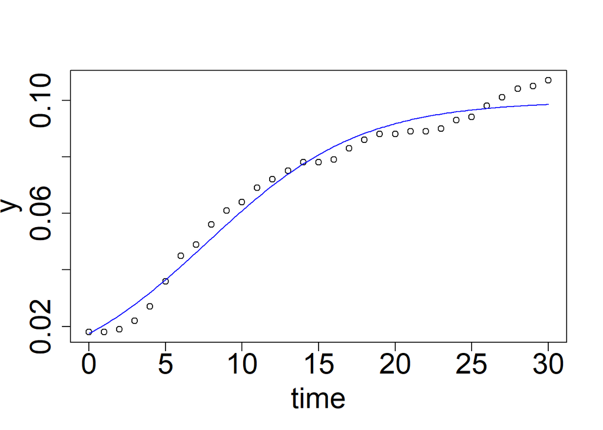

## Two-step differential equation model

Cells (or individuals) can be either inactive or active. For animals, inactive could mean an individual is not of reproductive age.

Each type has its own growth equation:

$$\frac{dy_i}{dt} = - k_w \cdot
y_i$$
$$\frac{dy_a}{dt} = k_w \cdot
y_i + \mu_{max} \cdot y_a \cdot \left( 1 - \frac{y_a+y_i}{K}
\right)$$

## Applying the two-step differential equation model

```r
p <- c(yi = 0.02, ya = 0.001, kw = 0.1, mumax = 0.2, K = 0.1)

fit2 <- fit_growthmodel(FUN = grow_twostep,
                        p = p,
                        time = dat$time,
                        y = dat$value)

coef(fit2)
```

## Plotting result of two-step model

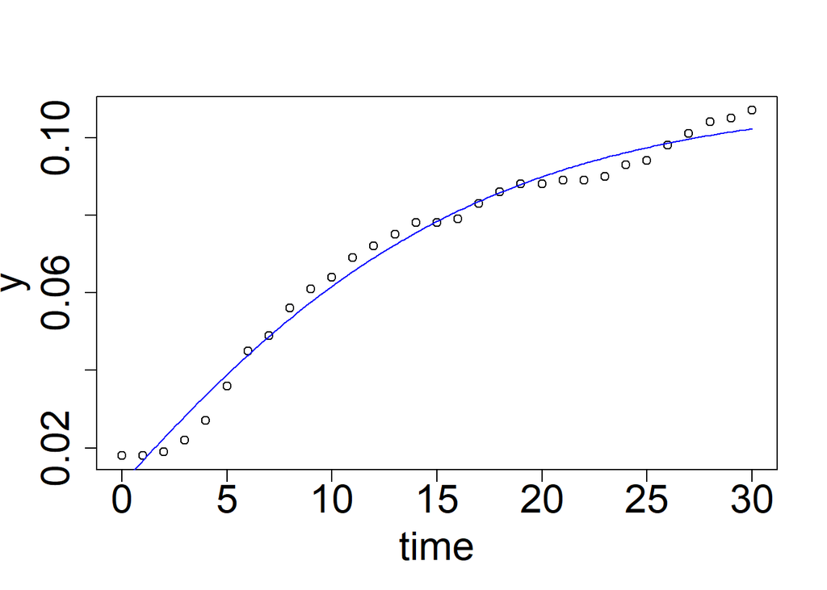

## Fitting models to multiple datasets

This applies when you have more than one growth curve. In `bactgrowth` we have a total of 72 growth curves, a combination of three strains, two replicates, and 12 different concentrations.

## Full `bactgrowth` dataset

Remember this plot of a subset with only four concentrations:

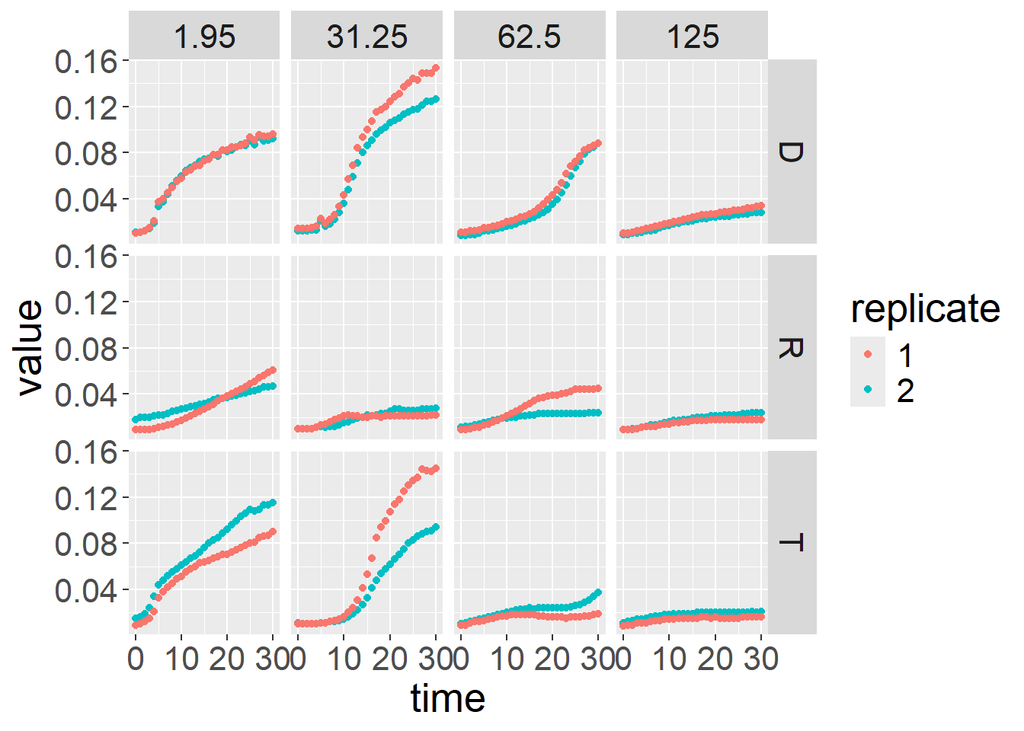

It’s clear why this package is often used for bacteria.

## Analysis of multiple datasets

One question we might ask ourselves is: how does the concentration of an antibiotic affect growth rates of different strains and replicates? This is known as dose response curves. The same logic applies to, for example, environmental toxins.

We start with a spline fit. `spar` is a parameter that determines smoothness of the spline fit. The output gives us estimates for $y_0$ and $r_{max}$.

```r
many_spline_fits <- all_splines(value ~ time |
                                  strain + conc + replicate,
                                data = bactgrowth, spar = 0.5)
```

## Look at coefficients

```r
head(coef(many_spline_fits), 5)
```

## Plotting results for multiple splines

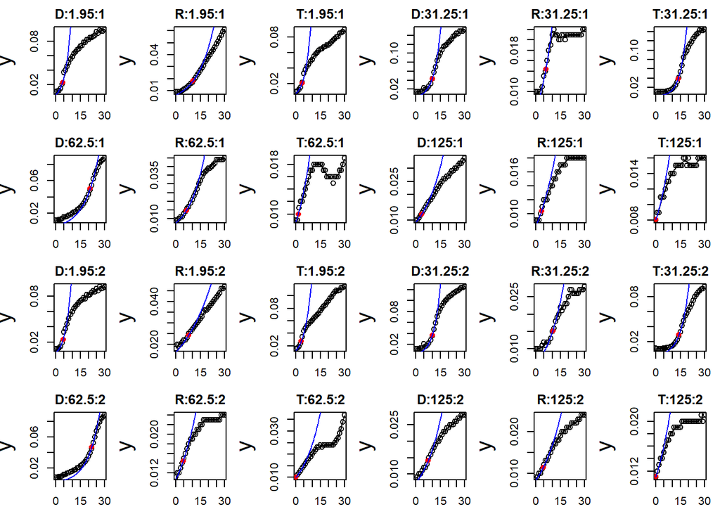

Very simple to display many graphs with only a few lines of code.

## Logistic growth models for multiple datasets

all_growthmodels(  
formula,  
data,  
p,  
lower = -Inf,  
upper = Inf,  
which = names(p),  
FUN = NULL,  
method = “Marq”,  
transform = c(“none”, “log”),  
…,  
subset = NULL,  
ncores = detectCores(logical = FALSE)  
)

## Applying `all_growthmodels` with logistic growth

```r
p   <- c(y0 = 0.03, mumax = .1, K = 0.1)

many_logistic <- all_growthmodels(
                   value ~ grow_logistic(time, parms) |
                     strain + conc + replicate,
                   data = bactgrowth,
                   p = p)
```

## Plotting results

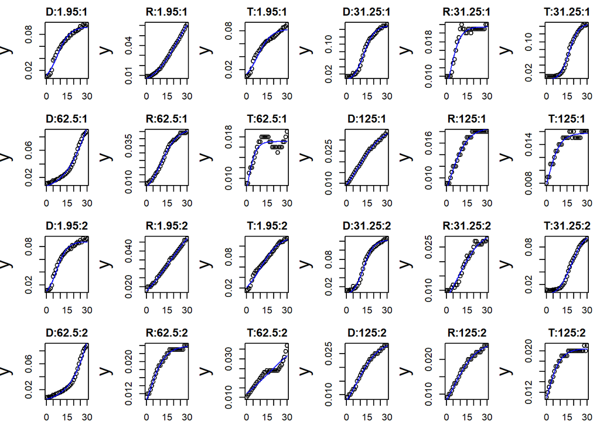

## Using results to estimate dose response curves

```r
many_spline_res   <- results(many_spline_fits)
many_logistic_res <- results(many_logistic)
```

## Plotting dose response curves for splines

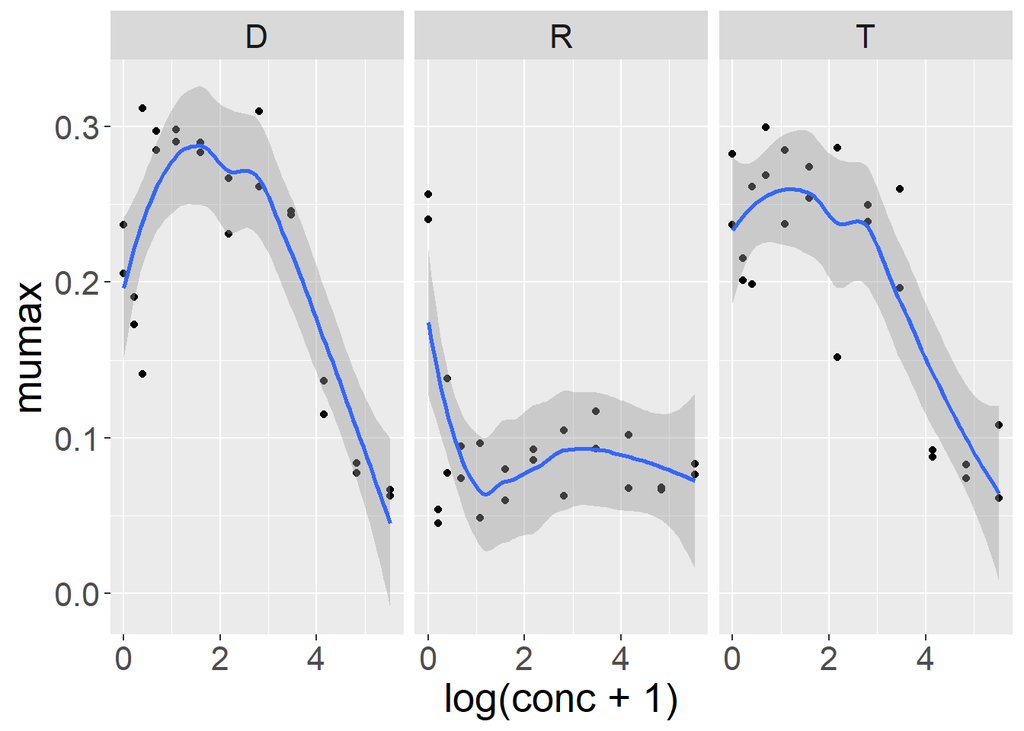

## Plotting dose response curves for logistic

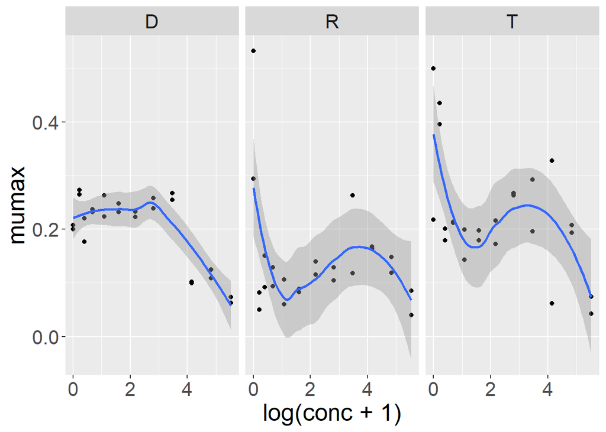

## Unique insight

You can write your own functions!

Example for a shift model (won’t go into details of the model)

$$y(t) = \frac{K \cdot y_0}{y_0 + (K-y_0)
\cdot e^{-\mu_{max}t}} + y_{shift}$$

## Code

```r
# Define model
grow_logistic_yshift <- function(time, parms) {
  with(as.list(parms), {
    y <- (K * y0) / (y0 + (K - y0) * exp(-mumax * time)) + y_shift
    as.matrix(data.frame(time = time, y = y))
  })
}

# Convert to class `growthmodel`
grow_logistic_yshift <- growthmodel(grow_logistic_yshift,
                                    c("y0", "mumax", "K", "y_shift"))

# Now use `growthrates` function to fit model
# fit <- fit_growthmodel(grow_logistic_yshift,
                       # p = c(y0 = 1, mumax = 0.1, K = 10, K = 10,
                       #       y_shift = 1),
                       # time = x, y = y)
```

## Advantages of `growthrates` package

- Adapted to problems of biological growth
- A lot simpler to use than the packages that contain the fitting routines
- Very flexible – can fit several different models; each function can be adapted
- Seems relatively fast
- Allows for user-defined functions
- Has built-in plotting function but also works well with ggplot
- Well documented

## Limitations of the package

- Would be even easier if some of the user-defined functions (like the shift model) were integrated into the package
- Overall the package does what it sets out to do, and I have no major complaints

## Sources

https://tpetzoldt.github.io/growthrates/doc/Introduction.html https://cran.r-project.org/web/packages/growthrates/growthrates.pdf https://github.com/tpetzoldt/growthrates

My code:

https://github.com/linusblomqvist/ESM_211/blob/main/growthrates/growthrates_prez.Rmd

## Portfolio assignment

Find $r$ and $K$ for the bison dataset using at least three different models (e.g. exponential, logistic, spline).

Hint: try functions `fit_easylinear`, `fit_growthmodels`, and `fit_splines`.

Do the different models agree on the parameter values?

Switching from bacteria to bison:

```r
### Read in bison data

bison <- read_csv(here("growthrates", "bison.csv")) %>%
  mutate(time = year - year[1]) ### remember time has to start from 0
```

Starting with `fit_easylinear`

```r
bison_fit <- fit_easylinear(bison$time, bison$bison)

# Keeping defaults for h and quota

coef(bison_fit)
```

$r = 0.13$

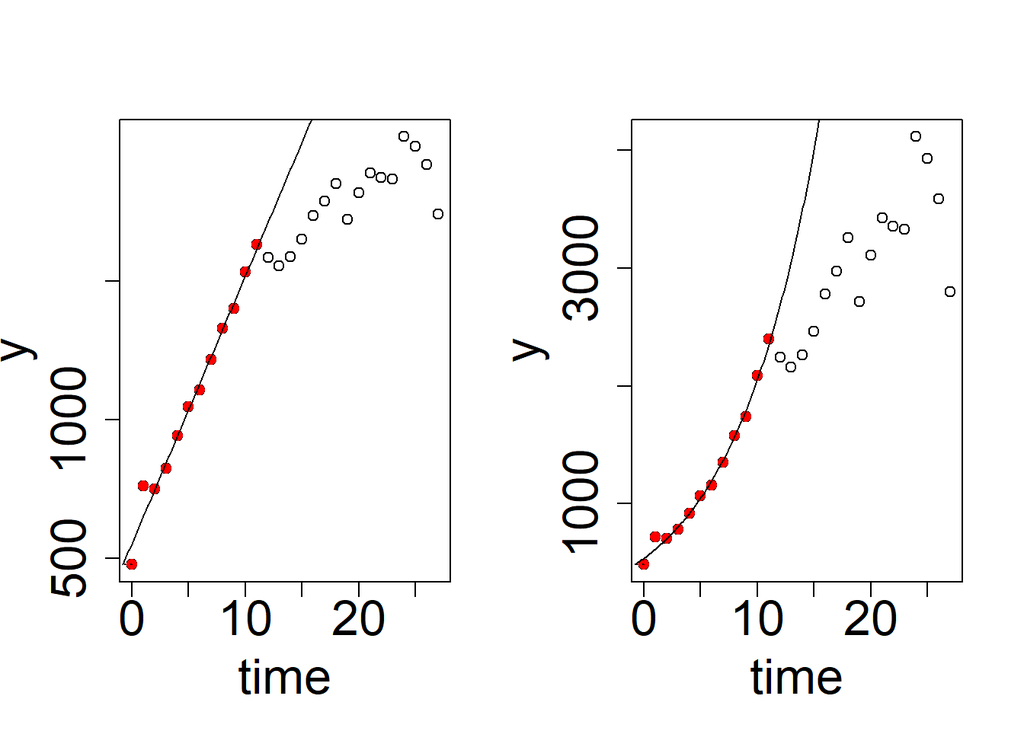

```r
par(mfrow = c(1, 2))
plot(bison_fit, log = "y", cex.lab = 2, cex.axis = 2)
plot(bison_fit, cex.lab = 2, cex.axis = 2)
```

Not the greatest fit.

Moving on to `fit_spline`

```r
bison_res <- fit_spline(bison$time, bison$bison)

coef(bison_res)
```

$r = 0.51$. That’s a bit of a difference.

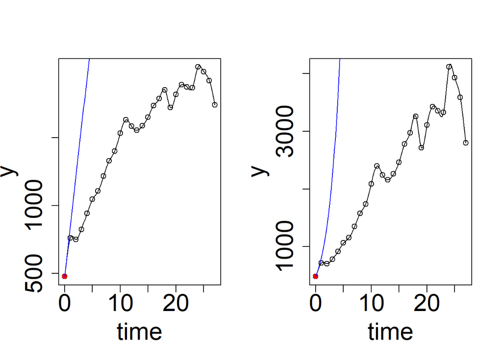

```r
par(mfrow = c(1, 2))
plot(bison_res, log = "y", cex.lab = 2, cex.axis = 2)
plot(bison_res, cex.lab = 2, cex.axis = 2)
```

Visually, I would call that an overestimation of r.

Let’s try `fit_growthmodel`

```r
bison_p <- c(y0 = 484, mumax = 0.2, K = 4114) ### making my best guess best on the graphs

bison_fit1 <- fit_growthmodel(FUN = grow_logistic,
                        p = bison_p,
                        bison$time,
                        bison$bison)

coef(bison_fit1)
```

$r = 0.18$ and $K = 3742$. Not terrible. r makes a little more sense with this model. K seems like it could be a bit of an underestimation.

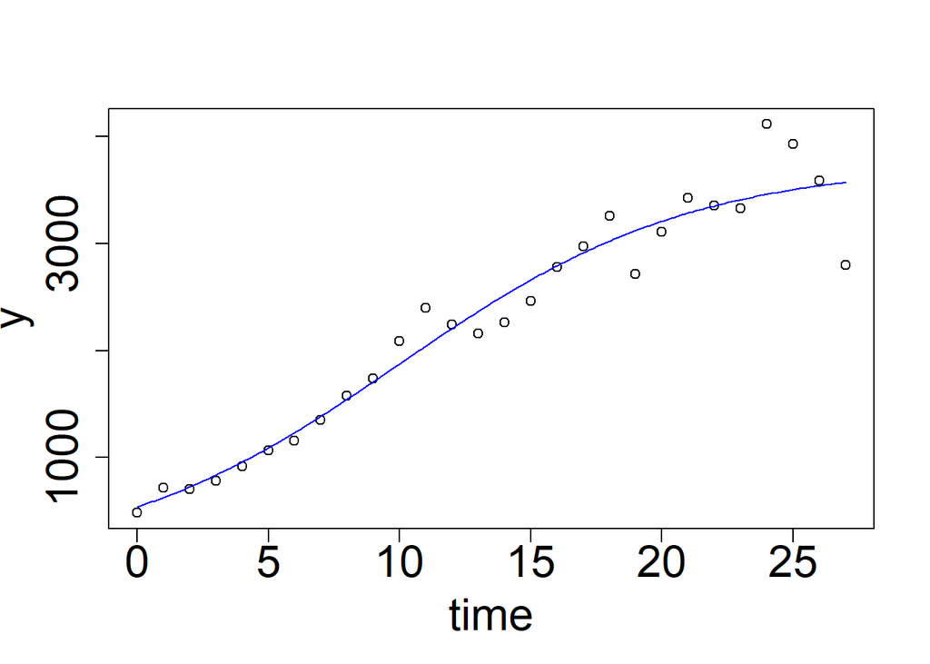

```r
plot(bison_fit1, cex.lab = 2, cex.axis = 2)
```

Visually, looks like a better fit than the other two.

Useful package. Definitely have to be familiar with your data before deciding on which model you want to use, though that is good practice regardless.